# testing revision

Erin M. Buchanan

6/14/2019

## Import both data

```r
pilot = read.csv("Melted Data pilot.csv", stringsAsFactors = F)
thesis = read.csv("Melted Data Thesis.csv", stringsAsFactors = F)

thesis$Partno = thesis$Partno + 1000
pilot$where = "pilot"
thesis$where = "thesis"

colnames(pilot)[2] = "Judgment"

master = rbind(pilot, thesis)

nrow(master)
```

```
## [1] 20979
```

## Merge with SWOW

```r
swow = read.csv("strength.SWOW-EN.R123.csv", stringsAsFactors = F)

swow$pair = paste(swow$cue, swow$response, sep = "_")
swow$pair = tolower(swow$pair)
swow$cue = tolower(swow$cue)
swow$response = tolower(swow$response)
swow = swow[-c(1001283) , ] #remove the dup

master$pair = gsub("...", "_", master$Word.Pair, fixed = T)
master$pair = tolower(master$pair)

master2 = merge(master, swow, by = "pair", all.x = T)
nrow(master2)
```

```
## [1] 20979
```

```r
##red yellow is duplicating - removing the duplicate line from swow

psych::describe(master2$R123.Strength)
```

```
##    vars     n mean   sd median trimmed  mad min  max range skew kurtosis
## X1    1 20204 0.06 0.07   0.03    0.05 0.04   0 0.28  0.28 1.47     1.29
##    se
## X1  0
```

```r
#normalize SWOW as the score is not number of participants who said X / number of participants, but instead is number of participants who said X / number of answers
#normalized = (x-min(x)) / (max(x) - min(x))

table(master2[is.na(master2$R123.Strength) , "pair"])
```

```
##
##     blue_eye   brick_wood cherry_apple   gold_jewel
##          221          221          112          221
```

```r
master2$swow_fsg = (master2$R123.Strength - min(master2$R123.Strength, na.rm = T)) / (max(master2$R123.Strength, na.rm = T) - min(master2$R123.Strength, na.rm = T))

master2$swow_fsg[is.na(master2$swow_fsg)] = 0

psych::describe(master2$swow_fsg)
```

```
##    vars     n mean   sd median trimmed  mad min max range skew kurtosis se
## X1    1 20979  0.2 0.24   0.11    0.16 0.15   0   1     1 1.51     1.43  0
```

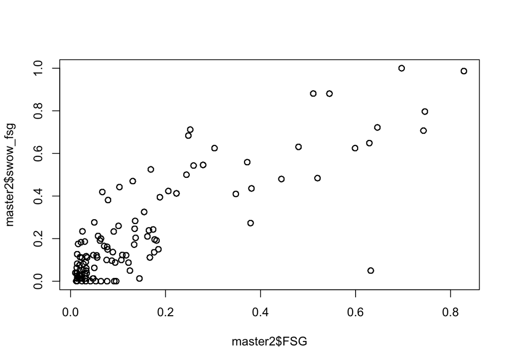

```r
plot(master2$FSG, master2$swow_fsg)
```

Here we would treat SWOW as the “first order associations” described in the reviewers suggestion.

## Create the 2nd order

Comparing the distributions of associative norms = finding the cosine between each cue-target words response sets.

```r
library(lsa)
paired = unique(master2$pair)
paired = as.data.frame(paired)
paired$paired = as.character(paired$paired)
paired$cosine = NA

for (i in 1:length(paired$paired)){ #loop over each word

  words = strsplit(paired$paired[i], "_")
  temp1 = swow[tolower(swow$cue) == words[[1]][1], ]
  temp2 = swow[tolower(swow$cue) == words[[1]][2], ]

  temp_merge = merge(temp1, temp2, by = "response", all = T)
  temp_merge$R123.Strength.x[is.na(temp_merge$R123.Strength.x)] = 0
  temp_merge$R123.Strength.y[is.na(temp_merge$R123.Strength.y)] = 0

  paired$cosine[i] = lsa::cosine(temp_merge$R123.Strength.x, temp_merge$R123.Strength.y)

}

#merge with  our data
colnames(paired)[1] = "pair"
master3 = merge(paired, master2, by = "pair")
```

## Let’s compare our variables

- The SWOW fsg is pretty similar to the regular FSG … check.
- Unrelated to the distribution of the responses, interesting (cosine).
- COS (ours) to cosine (distribution) is pretty high, that’s good.
- LSA here is the same relation to swow_fsg as before FSG, and less related to this new cosine.

```r
vars = c("swow_fsg", "cosine", "COS", "LSA", "FSG")
cor(master3[ , vars])
```

```
##           swow_fsg     cosine       COS       LSA        FSG
## swow_fsg 1.0000000 0.14785074 0.3286874 0.4504840 0.83397030
## cosine   0.1478507 1.00000000 0.6242045 0.2869935 0.03307919
## COS      0.3286874 0.62420452 1.0000000 0.4950387 0.31773300
## LSA      0.4504840 0.28699353 0.4950387 1.0000000 0.43964581
## FSG      0.8339703 0.03307919 0.3177330 0.4396458 1.00000000
```

```r
#scaling judgments
master3$Judged.Value = master3$Judged.Value / 100

#clean up judgment type
master3$Judgment = gsub("semantic", "Semantic", master3$Judgment)
master3$Judgment = gsub("associative", "Associative", master3$Judgment)
master3$Judgment = gsub("thematic", "Thematic", master3$Judgment)
```

## Hypothesis 1

```r
##are average slope and intercept values greater than zero?
##are they within the range of previous work, although maybe controlling for other variables might change them a bit
##frequency of strongest predictor

####try a loop####
##setup
persontable = matrix(NA,
                     nrow=length(names(table(master3$Partno))),
                     ncol=10)
colnames(persontable) = c("Partno", "AIntercept", "ACOS", "AFSG",
                          "SIntercept", "SCOS", "SFSG",
                          "TIntercept", "TCOS", "TFSG")
simnum = 1

for ( person in names(table(master3$Partno)) ){ ##loop over participants

  temp1 = subset(master3, Partno == person & Judgment == "Associative")
  temp2 = subset(master3, Partno == person & Judgment == "Semantic")
  temp3 = subset(master3, Partno == person & Judgment == "Thematic")

  persontable[ simnum , 1] = person

  if (sum(!is.na(temp1$Judged.Value)) > 9) {
    model9 = lm(Judged.Value ~ cosine + swow_fsg, data = temp1)
    persontable[ simnum , 2:4] = model9$coefficients
  }

  if(sum(!is.na(temp2$Judged.Value)) > 9) {
    model10 = lm(Judged.Value ~ cosine + swow_fsg, data = temp2)
    persontable[ simnum , 5:7] = model10$coefficients
  }

  if(sum(!is.na(temp3$Judged.Value)) > 9) {
    model11 = lm(Judged.Value ~ cosine + swow_fsg, data = temp3)
    persontable[ simnum , 8:10] = model11$coefficients
  }

  simnum = simnum + 1

}

##set up the output
people = apply(persontable, 2, as.numeric)
people = as.data.frame(people)

####hyp 1 are these greater than zero####
##single sample t-test for each column, focus on the effect size
library(MOTE)
library(knitr)

p.value = function(x){
  if (x < .001) { return("< .001")}
  else { return(apa(x, 3, F))}
}

hyp1results = apply(people[ , -1], 2, function (x) { d.single.t(m = mean(x, na.rm = T),
                                u = 0,
                                sd = sd(x, na.rm = T),
                                n = sum(!is.na(x)),
                                a = .05)})
```

[output not shown]

```r
##what happened? make a table
##create a blank table
tableprint = matrix(NA, nrow = 9, ncol = 8)
colnames(tableprint) = c("Variable", "$M$", "$SD$", "$t$", "$df$", "$p$", "$d$", "$95 CI$")

tableprint[1 , ] = c("Associative Intercept", apa(hyp1results$AIntercept$m, 3, F),
                     apa(hyp1results$AIntercept$sd, 3, F), apa(hyp1results$AIntercept$t, 3, T),
                     hyp1results$AIntercept$df, p.value(hyp1results$AIntercept$p),
                     apa(hyp1results$AIntercept$d, 3, T), paste(apa(hyp1results$AIntercept$dlow, 3, T),
                                                     "-", apa(hyp1results$AIntercept$dhigh, 3, T)))

tableprint[2 , ] = c("Associative COS", apa(hyp1results$ACOS$m, 3, F),
                     apa(hyp1results$ACOS$sd, 3, F), apa(hyp1results$ACOS$t, 3, T),
                     hyp1results$ACOS$df, p.value(hyp1results$ACOS$p),
                     apa(hyp1results$ACOS$d, 3, T), paste(apa(hyp1results$ACOS$dlow, 3, T),
                                                     "-", apa(hyp1results$ACOS$dhigh, 3, T)))

tableprint[3 , ] = c("Associative FSG", apa(hyp1results$AFSG$m, 3, F),
                     apa(hyp1results$AFSG$sd, 3, F), apa(hyp1results$AFSG$t, 3, T),
                     hyp1results$AFSG$df, p.value(hyp1results$AFSG$p),
                     apa(hyp1results$AFSG$d, 3, T), paste(apa(hyp1results$AFSG$dlow, 3, T),
                                                     "-", apa(hyp1results$AFSG$dhigh, 3, T)))

tableprint[4 , ] = c("Semantic Intercept", apa(hyp1results$SIntercept$m, 3, F),
                     apa(hyp1results$SIntercept$sd, 3, F), apa(hyp1results$SIntercept$t, 3, T),
                     hyp1results$SIntercept$df, p.value(hyp1results$SIntercept$p),
                     apa(hyp1results$SIntercept$d, 3, T), paste(apa(hyp1results$SIntercept$dlow, 3, T),
                                                     "-", apa(hyp1results$SIntercept$dhigh, 3, T)))

tableprint[5 , ] = c("Semantic COS", apa(hyp1results$SCOS$m, 3, F),
                     apa(hyp1results$SCOS$sd, 3, F), apa(hyp1results$SCOS$t, 3, T),
                     hyp1results$SCOS$df, p.value(hyp1results$SCOS$p),
                     apa(hyp1results$SCOS$d, 3, T), paste(apa(hyp1results$SCOS$dlow, 3, T),
                                                     "-", apa(hyp1results$SCOS$dhigh, 3, T)))

tableprint[6 , ] = c("Semantic FSG", apa(hyp1results$SFSG$m, 3, F),
                     apa(hyp1results$SFSG$sd, 3, F), apa(hyp1results$SFSG$t, 3, T),
                     hyp1results$SFSG$df, p.value(hyp1results$SFSG$p),
                     apa(hyp1results$SFSG$d, 3, T), paste(apa(hyp1results$SFSG$dlow, 3, T),
                                                     "-", apa(hyp1results$SFSG$dhigh, 3, T)))

tableprint[7 , ] = c("Thematic Intercept", apa(hyp1results$TIntercept$m, 3, F),
                     apa(hyp1results$TIntercept$sd, 3, F), apa(hyp1results$TIntercept$t, 3, T),
                     hyp1results$TIntercept$df, p.value(hyp1results$TIntercept$p),
                     apa(hyp1results$TIntercept$d, 3, T), paste(apa(hyp1results$TIntercept$dlow, 3, T),
                                                     "-", apa(hyp1results$TIntercept$dhigh, 3, T)))

tableprint[8 , ] = c("Thematic COS", apa(hyp1results$TCOS$m, 3, F),
                     apa(hyp1results$TCOS$sd, 3, F), apa(hyp1results$TCOS$t, 3, T),
                     hyp1results$TCOS$df, p.value(hyp1results$TCOS$p),
                     apa(hyp1results$TCOS$d, 3, T), paste(apa(hyp1results$TCOS$dlow, 3, T),
                                                     "-", apa(hyp1results$TCOS$dhigh, 3, T)))

tableprint[9 , ] = c("Thematic FSG", apa(hyp1results$TFSG$m, 3, F),
                     apa(hyp1results$TFSG$sd, 3, F), apa(hyp1results$TFSG$t, 3, T),
                     hyp1results$TFSG$df, p.value(hyp1results$TFSG$p),
                     apa(hyp1results$TFSG$d, 3, T), paste(apa(hyp1results$TFSG$dlow, 3, T),
                                                     "-", apa(hyp1results$TFSG$dhigh, 3, T)))

kable(tableprint)
```

| Variable | $M$ | $SD$ | $t$ | $df$ | $p$ | $d$ | $95 CI$ |
| --- | --- | --- | --- | --- | --- | --- | --- |
| Associative Intercept | .521 | .201 | 45.767 | 311 | < .001 | 2.591 | 2.357 - 2.821 |
| Associative COS | .039 | .381 | 1.809 | 311 | .071 | 0.102 | -0.009 - 0.214 |
| Associative FSG | .321 | .341 | 16.603 | 311 | < .001 | 0.940 | 0.806 - 1.073 |
| Semantic Intercept | .519 | .235 | 39.089 | 312 | < .001 | 2.209 | 2.003 - 2.413 |
| Semantic COS | .242 | .386 | 11.089 | 312 | < .001 | 0.627 | 0.505 - 0.748 |
| Semantic FSG | .349 | .921 | 6.702 | 312 | < .001 | 0.379 | 0.264 - 0.493 |
| Thematic Intercept | .606 | .195 | 55.274 | 315 | < .001 | 3.109 | 2.840 - 3.374 |
| Thematic COS | .172 | .484 | 6.324 | 315 | < .001 | 0.356 | 0.242 - 0.469 |
| Thematic FSG | .264 | .291 | 16.133 | 315 | < .001 | 0.908 | 0.776 - 1.038 |

Comparison to original results: - Intercepts all pretty much the same over estimation effect - Assoc FSG > stronger / higher than before - Assoc cosine about the same - Semantic FSG > way stronger than before, makes a lot more damned sense - BECAUSE semantic cosine is now a thing! - Thematic fsg is about the same but now makes more sense becausee - Thematic cosine is a thing!

This result tells me: - interecepts are what we expect .4-.6 - slopes are mostly what we expect - slopes matter by instruction!

## Hypothesis 2

```r
##group them all by type
##dropping partno column
people_thematic = people[ , 8:10]
people_semantic = people[ , 5:7]
people_associative = people[ , 2:4]

##getting absolute values
people_thematic2 = abs(people_thematic)
people_semantic2 = abs(people_semantic)
people_associative2 = abs(people_associative)

##getting rid of the intercepts
people_thematic3 = people_thematic2[ , -1]
people_semantic3 = people_semantic2[ , -1]
people_associative3 = people_associative2[ , -1]

##finding max coefficents for each row
thematic_output = names(people_thematic3)[max.col(people_thematic3, ties.method="first")]
thematic_output = as.data.frame(thematic_output)

semantic_output = names(people_semantic3)[max.col(people_semantic3, ties.method="first")]
semantic_output = as.data.frame(semantic_output)

associative_output = names(people_associative3)[max.col(people_associative3, ties.method="first")]
associative_output = as.data.frame(associative_output)

##sticking it all together
combined = cbind(people$Partno, associative_output, semantic_output, thematic_output)
colnames(combined) = c("Partno", "Associative", "Semantic", "Thematic")

##rename the things
combined$Associative = factor(combined$Associative,
                           labels = c("COS", "FSG"))
combined$Semantic = factor(combined$Semantic,
                           labels = c("COS", "FSG"))
combined$Thematic = factor(combined$Thematic,
                           labels = c("COS", "FSG"))
summary(combined[ , -1])
```

```
##  Associative Semantic   Thematic
##  COS :102    COS :152   COS :147
##  FSG :210    FSG :161   FSG :169
##  NA's: 22    NA's: 21   NA's: 18
```

```r
##what are the percentages on these?
library(memisc)
p1 = percent(combined$Associative)
p1
```

```
##       COS       FSG         N
##  32.69231  67.30769 312.00000
```

```r
p2 = percent(combined$Semantic)
p2
```

```
##      COS      FSG        N
##  48.5623  51.4377 313.0000
```

```r
p3 = percent(combined$Thematic)
p3
```

```
##       COS       FSG         N
##  46.51899  53.48101 316.00000
```

- Previously FSG predicted assoc at 64 now 67
- FSG for semantic was highest with 44, now we are seeing even split
- FSG for thematic was 37 with basically nothing for cosine now seeing more even split

## A two level interaction for Hypothesis 2 for JOR

```r
library(nlme)

#center the vars
master3$zfsg = scale(master3$swow_fsg, scale = F)
master3$zcosine = scale(master3$cosine, scale = F)

overallh2 = lme(Judged.Value ~ Judgment +
               zfsg*zcosine,
             data = master3,
             method = "ML",
             na.action = "na.omit",
             random = ~1|Partno)

summary(overallh2)
```

```
## Linear mixed-effects model fit by maximum likelihood
##  Data: master3
##        AIC      BIC    logLik
##   21516.09 21579.21 -10750.04
##
## Random effects:
##  Formula: ~1 | Partno
##         (Intercept)  Residual
## StdDev:   0.1208094 0.4108751
##
## Fixed effects: Judged.Value ~ Judgment + zfsg * zcosine
##                       Value  Std.Error    DF  t-value p-value
## (Intercept)       0.5978476 0.00848148 19418 70.48861       0
## JudgmentSemantic  0.0563833 0.00719559 19418  7.83581       0
## JudgmentThematic  0.1067562 0.00718102 19418 14.86643       0
## zfsg              0.3070734 0.01215124 19418 25.27096       0
## zcosine           0.1434987 0.01485158 19418  9.66218       0
## zfsg:zcosine     -0.3861958 0.07968693 19418 -4.84641       0
##  Correlation:
##                  (Intr) JdgmnS JdgmnT zfsg   zcosin
## JudgmentSemantic -0.424
## JudgmentThematic -0.426  0.502
## zfsg              0.004 -0.004 -0.007
## zcosine          -0.011 -0.001  0.000 -0.150
## zfsg:zcosine     -0.071  0.008  0.000 -0.014  0.153
##
## Standardized Within-Group Residuals:
##         Min          Q1         Med          Q3         Max
## -2.46004578 -0.41812530  0.07480203  0.44605324 82.78103827
##
## Number of Observations: 19747
## Number of Groups: 324
```

## What is the interaction

```r
#split on cosine because that's what we did before
master3$low_cosine = master3$zcosine + sd(master3$zcosine)
master3$high_cosine = master3$zcosine - sd(master3$zcosine)

overallh2_low = lme(Judged.Value ~ Judgment +
               zfsg*low_cosine,
             data = master3,
             method = "ML",
             na.action = "na.omit",
             random = ~1|Partno)

summary(overallh2_low) ##.38
```

```
## Linear mixed-effects model fit by maximum likelihood
##  Data: master3
##        AIC      BIC    logLik
##   21516.09 21579.21 -10750.04
##
## Random effects:
##  Formula: ~1 | Partno
##         (Intercept)  Residual
## StdDev:   0.1208094 0.4108751
##
## Fixed effects: Judged.Value ~ Judgment + zfsg * low_cosine
##                       Value  Std.Error    DF  t-value p-value
## (Intercept)       0.5689292 0.00902440 19418 63.04344       0
## JudgmentSemantic  0.0563833 0.00719559 19418  7.83581       0
## JudgmentThematic  0.1067562 0.00718102 19418 14.86643       0
## zfsg              0.3849009 0.02027411 19418 18.98485       0
## low_cosine        0.1434987 0.01485158 19418  9.66218       0
## zfsg:low_cosine  -0.3861958 0.07968693 19418 -4.84641       0
##  Correlation:
##                  (Intr) JdgmnS JdgmnT zfsg   lw_csn
## JudgmentSemantic -0.399
## JudgmentThematic -0.401  0.502
## zfsg              0.125 -0.009 -0.004
## low_cosine       -0.342 -0.001  0.000 -0.211
## zfsg:low_cosine  -0.118  0.008  0.000 -0.801  0.153
##
## Standardized Within-Group Residuals:
##         Min          Q1         Med          Q3         Max
## -2.46004578 -0.41812530  0.07480203  0.44605324 82.78103827
##
## Number of Observations: 19747
## Number of Groups: 324
```

```r
summary(overallh2) ##.30
```

```
## Linear mixed-effects model fit by maximum likelihood
##  Data: master3
##        AIC      BIC    logLik
##   21516.09 21579.21 -10750.04
##
## Random effects:
##  Formula: ~1 | Partno
##         (Intercept)  Residual
## StdDev:   0.1208094 0.4108751
##
## Fixed effects: Judged.Value ~ Judgment + zfsg * zcosine
##                       Value  Std.Error    DF  t-value p-value
## (Intercept)       0.5978476 0.00848148 19418 70.48861       0
## JudgmentSemantic  0.0563833 0.00719559 19418  7.83581       0
## JudgmentThematic  0.1067562 0.00718102 19418 14.86643       0
## zfsg              0.3070734 0.01215124 19418 25.27096       0
## zcosine           0.1434987 0.01485158 19418  9.66218       0
## zfsg:zcosine     -0.3861958 0.07968693 19418 -4.84641       0
##  Correlation:
##                  (Intr) JdgmnS JdgmnT zfsg   zcosin
## JudgmentSemantic -0.424
## JudgmentThematic -0.426  0.502
## zfsg              0.004 -0.004 -0.007
## zcosine          -0.011 -0.001  0.000 -0.150
## zfsg:zcosine     -0.071  0.008  0.000 -0.014  0.153
##
## Standardized Within-Group Residuals:
##         Min          Q1         Med          Q3         Max
## -2.46004578 -0.41812530  0.07480203  0.44605324 82.78103827
##
## Number of Observations: 19747
## Number of Groups: 324
```

```r
overallh2_high = lme(Judged.Value ~ Judgment +
               zfsg*high_cosine,
             data = master3,
             method = "ML",
             na.action = "na.omit",
             random = ~1|Partno)

summary(overallh2_high) ##.22
```

```
## Linear mixed-effects model fit by maximum likelihood
##  Data: master3
##        AIC      BIC    logLik
##   21516.09 21579.21 -10750.04
##
## Random effects:
##  Formula: ~1 | Partno
##         (Intercept)  Residual
## StdDev:   0.1208094 0.4108751
##
## Fixed effects: Judged.Value ~ Judgment + zfsg * high_cosine
##                       Value  Std.Error    DF  t-value p-value
## (Intercept)       0.6267659 0.00896362 19418 69.92330       0
## JudgmentSemantic  0.0563833 0.00719559 19418  7.83581       0
## JudgmentThematic  0.1067562 0.00718102 19418 14.86643       0
## zfsg              0.2292459 0.02000087 19418 11.46180       0
## high_cosine       0.1434987 0.01485158 19418  9.66218       0
## zfsg:high_cosine -0.3861958 0.07968693 19418 -4.84641       0
##  Correlation:
##                  (Intr) JdgmnS JdgmnT zfsg   hgh_cs
## JudgmentSemantic -0.402
## JudgmentThematic -0.403  0.502
## zfsg             -0.041  0.005 -0.005
## high_cosine       0.324 -0.001  0.000  0.032
## zfsg:high_cosine -0.016  0.008  0.000  0.794  0.153
##
## Standardized Within-Group Residuals:
##         Min          Q1         Med          Q3         Max
## -2.46004578 -0.41812530  0.07480203  0.44605324 82.78103827
##
## Number of Observations: 19747
## Number of Groups: 324
```

So, what we see is at low levels of cosine, FSG is pulling the weight, but as cosine increases, the effect of FSG decreases (see-sawing).

## Recall for Hypothesis 3

```r
library(lme4)
recalloverall = glmer(Recall ~ (1|Partno) + Judgment +
                        Judged.Value + zfsg*zcosine,
                      data = master3,
                      family = binomial,
                      control = glmerControl(optimizer = "bobyqa"),
                      nAGQ = 0)
summary(recalloverall) ##1.63
```

```
## Generalized linear mixed model fit by maximum likelihood (Adaptive
##   Gauss-Hermite Quadrature, nAGQ = 0) [glmerMod]
##  Family: binomial  ( logit )
## Formula: Recall ~ (1 | Partno) + Judgment + Judged.Value + zfsg * zcosine
##    Data: master3
## Control: glmerControl(optimizer = "bobyqa")
##
##      AIC      BIC   logLik deviance df.resid
##  21415.9  21478.6 -10700.0  21399.9    18717
##
## Scaled residuals:
##     Min      1Q  Median      3Q     Max
## -6.3439 -0.8166  0.3937  0.6892  4.8809
##
## Random effects:
##  Groups Name        Variance Std.Dev.
##  Partno (Intercept) 1.41     1.187
## Number of obs: 18725, groups:  Partno, 318
##
## Fixed effects:
##                  Estimate Std. Error z value Pr(>|z|)
## (Intercept)       0.42369    0.07969   5.316 1.06e-07 ***
## JudgmentSemantic  0.18159    0.04166   4.359 1.30e-05 ***
## JudgmentThematic  0.04416    0.04160   1.061 0.288474
## Judged.Value      0.04163    0.05176   0.804 0.421254
## zfsg              1.63309    0.07938  20.572  < 2e-16 ***
## zcosine           0.32433    0.08734   3.713 0.000205 ***
## zfsg:zcosine     -1.29837    0.48704  -2.666 0.007679 **
## ---
## Signif. codes:  0 '***' 0.001 '**' 0.01 '*' 0.05 '.' 0.1 ' ' 1
##
## Correlation of Fixed Effects:
##             (Intr) JdgmnS JdgmnT Jdgd.V zfsg   zcosin
## JdgmntSmntc -0.232
## JdgmntThmtc -0.204  0.500
## Judged.Valu -0.385 -0.061 -0.139
## zfsg         0.102  0.019  0.022 -0.202
## zcosine      0.027  0.004  0.013 -0.094 -0.145
## zfsg:zcosin -0.059  0.002 -0.006  0.030 -0.051  0.228
```

```r
recalloverall_low = glmer(Recall ~ (1|Partno) + Judgment +
                        Judged.Value + zfsg*low_cosine,
                      data = master3,
                      family = binomial,
                      control = glmerControl(optimizer = "bobyqa"),
                      nAGQ = 0)

summary(recalloverall_low) #1.89
```

```
## Generalized linear mixed model fit by maximum likelihood (Adaptive
##   Gauss-Hermite Quadrature, nAGQ = 0) [glmerMod]
##  Family: binomial  ( logit )
## Formula:
## Recall ~ (1 | Partno) + Judgment + Judged.Value + zfsg * low_cosine
##    Data: master3
## Control: glmerControl(optimizer = "bobyqa")
##
##      AIC      BIC   logLik deviance df.resid
##  21415.9  21478.6 -10700.0  21399.9    18717
##
## Scaled residuals:
##     Min      1Q  Median      3Q     Max
## -6.3439 -0.8166  0.3937  0.6892  4.8809
##
## Random effects:
##  Groups Name        Variance Std.Dev.
##  Partno (Intercept) 1.41     1.187
## Number of obs: 18725, groups:  Partno, 318
##
## Fixed effects:
##                  Estimate Std. Error z value Pr(>|z|)
## (Intercept)       0.35833    0.08116   4.415 1.01e-05 ***
## JudgmentSemantic  0.18159    0.04166   4.359 1.30e-05 ***
## JudgmentThematic  0.04416    0.04160   1.061 0.288474
## Judged.Value      0.04163    0.05176   0.804 0.421254
## zfsg              1.89474    0.12933  14.650  < 2e-16 ***
## low_cosine        0.32433    0.08734   3.713 0.000205 ***
## zfsg:low_cosine  -1.29837    0.48704  -2.666 0.007679 **
## ---
## Signif. codes:  0 '***' 0.001 '**' 0.01 '*' 0.05 '.' 0.1 ' ' 1
##
## Correlation of Fixed Effects:
##             (Intr) JdgmnS JdgmnT Jdgd.V zfsg   lw_csn
## JdgmntSmntc -0.229
## JdgmntThmtc -0.203  0.500
## Judged.Valu -0.358 -0.061 -0.139
## zfsg         0.163  0.010  0.018 -0.147
## low_cosine  -0.191  0.004  0.013 -0.094 -0.262
## zfsg:lw_csn -0.108  0.002 -0.006  0.030 -0.790  0.228
```

```r
recalloverall_high = glmer(Recall ~ (1|Partno) + Judgment +
                        Judged.Value + zfsg*high_cosine,
                      data = master3,
                      family = binomial,
                      control = glmerControl(optimizer = "bobyqa"),
                      nAGQ = 0)

summary(recalloverall_high) #1.37
```

```
## Generalized linear mixed model fit by maximum likelihood (Adaptive
##   Gauss-Hermite Quadrature, nAGQ = 0) [glmerMod]
##  Family: binomial  ( logit )
## Formula:
## Recall ~ (1 | Partno) + Judgment + Judged.Value + zfsg * high_cosine
##    Data: master3
## Control: glmerControl(optimizer = "bobyqa")
##
##      AIC      BIC   logLik deviance df.resid
##  21415.9  21478.6 -10700.0  21399.9    18717
##
## Scaled residuals:
##     Min      1Q  Median      3Q     Max
## -6.3439 -0.8166  0.3937  0.6892  4.8809
##
## Random effects:
##  Groups Name        Variance Std.Dev.
##  Partno (Intercept) 1.41     1.187
## Number of obs: 18725, groups:  Partno, 318
##
## Fixed effects:
##                  Estimate Std. Error z value Pr(>|z|)
## (Intercept)       0.48905    0.08207   5.959 2.54e-09 ***
## JudgmentSemantic  0.18159    0.04166   4.359 1.30e-05 ***
## JudgmentThematic  0.04416    0.04160   1.061 0.288474
## Judged.Value      0.04163    0.05176   0.804 0.421254
## zfsg              1.37143    0.12306  11.145  < 2e-16 ***
## high_cosine       0.32433    0.08734   3.713 0.000205 ***
## zfsg:high_cosine -1.29837    0.48704  -2.666 0.007679 **
## ---
## Signif. codes:  0 '***' 0.001 '**' 0.01 '*' 0.05 '.' 0.1 ' ' 1
##
## Correlation of Fixed Effects:
##             (Intr) JdgmnS JdgmnT Jdgd.V zfsg   hgh_cs
## JdgmntSmntc -0.225
## JdgmntThmtc -0.195  0.500
## Judged.Valu -0.394 -0.061 -0.139
## zfsg         0.037  0.014  0.009 -0.106
## high_cosine  0.240  0.004  0.013 -0.094  0.088
## zfsg:hgh_cs -0.009  0.002 -0.006  0.030  0.765  0.228
```

Find the exact same pattern!

## Hypothesis 4

```r
##merge recall back with slopes from the people dataset
hyp4data = merge(people, master3, by = "Partno")

##association
assoch4 = glmer(Recall ~ (1|Partno) + ACOS + AFSG + AIntercept,
                data = hyp4data,
                family = binomial,
                control = glmerControl(optimizer = "bobyqa"),
                nAGQ = 1)

##semantics
semh4 = glmer(Recall ~ (1|Partno) + SCOS + SFSG + SIntercept,
                data = hyp4data,
                family = binomial,
                control = glmerControl(optimizer = "bobyqa"),
                nAGQ = 1)

##thematics
themeh4 = glmer(Recall ~ (1|Partno) + TCOS + TFSG + TIntercept,
                data = hyp4data,
                family = binomial,
                control = glmerControl(optimizer = "bobyqa"),
                nAGQ = 1)

####table set up####
##create a blank table
tableprint = matrix(NA, nrow = 12, ncol = 5)
colnames(tableprint) = c("Variable", "$b$", "$SE$", "$z$", "$p$")

tableprint[1:4, 2:5] = coef(summary(assoch4))
tableprint[1:4, 1] = dimnames(coef(summary(assoch4)))[[1]]

tableprint[5:8, 2:5] = coef(summary(semh4))
tableprint[5:8, 1] = dimnames(coef(summary(semh4)))[[1]]

tableprint[9:12, 2:5] = coef(summary(themeh4))
tableprint[9:12, 1] = dimnames(coef(summary(themeh4)))[[1]]

library(papaja)
tableprint[ , 2] = apa(as.numeric(tableprint[ , 2]),3,T)
tableprint[ , 3] = apa(as.numeric(tableprint[ , 3]),3,T)
tableprint[ , 4] = apa(as.numeric(tableprint[ , 4]),3,T)
tableprint[ , 5] = apply(as.data.frame(as.numeric(tableprint[ , 5])), 1, p.value)

kable(tableprint)
```

| Variable | $b$ | $SE$ | $z$ | $p$ |
| --- | --- | --- | --- | --- |
| (Intercept) | 0.006 | 0.268 | 0.022 | .982 |
| ACOS | 0.084 | 0.201 | 0.416 | .678 |
| AFSG | 0.978 | 0.243 | 4.029 | < .001 |
| AIntercept | 0.390 | 0.392 | 0.994 | .320 |
| (Intercept) | -0.626 | 0.284 | -2.200 | .028 |
| SCOS | 1.258 | 0.224 | 5.614 | < .001 |
| SFSG | 0.465 | 0.110 | 4.218 | < .001 |
| SIntercept | 1.282 | 0.410 | 3.130 | .002 |
| (Intercept) | -0.748 | 0.316 | -2.368 | .018 |
| TCOS | 0.606 | 0.173 | 3.510 | < .001 |
| TFSG | 1.013 | 0.259 | 3.917 | < .001 |
| TIntercept | 1.447 | 0.418 | 3.462 | < .001 |

- Association: we found before that fsg slope predicts best then cosine
  - Now seeing fsg with no cosine
- Semantics: we found before that cosine predicts best then fsg
  - now seeing same thing
- Thematics: cosine then negative fsg
  - now seeing fsg then cosine

# TLDR

- Similiar results with maybe less confusion on variables, not mixing types, and no three way interactions!
- Combine thesis and pilot data
  - Still hang on to thesis ideas for part 2 looking at single word variables contributions for a second paper (if you want)
- Switch to this idea of a direct versus indirect relationship?